# Plot Rivers Inlet Sockeye Salmon State-Space Spawner-Recruitment Model Results

B. Connors

21 November, 2020

# 1 Purpose

The purpose of this document is to summarize spawner-recruitment model output and diagnostics in a unified format for ease of review.

# 2 Basic Convergence Diagnostics

## 2.1 Effective Sample Size

Ideally effective sample sizes are > 400.

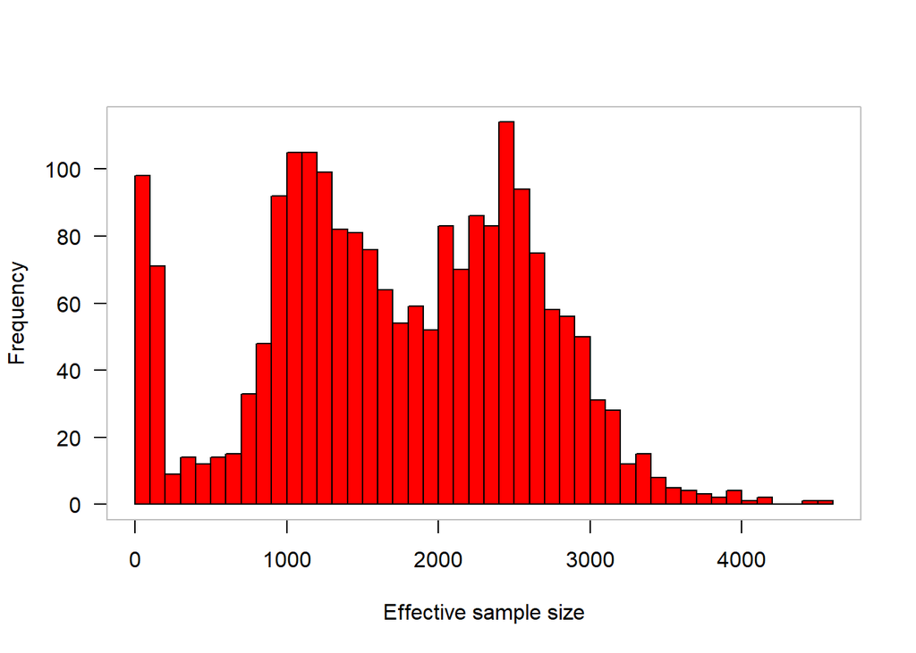

## 2.2 R-hat Convergence Diagnostic

Compares the between- and within-chain estimates for model parameters and other univariate quantities of interest. If chains have not mixed well (i.e., the between- and within-chain estimates don’t agree), R-hat is larger than 1. We recommend running at least four chains by default and only using the sample if R-hat is less than 1.05. Stan reports R-hat which is the maximum of rank normalized split-R-hat and rank normalized folded-split-R-hat, which works for thick tailed distributions and is sensitive also to differences in scale.

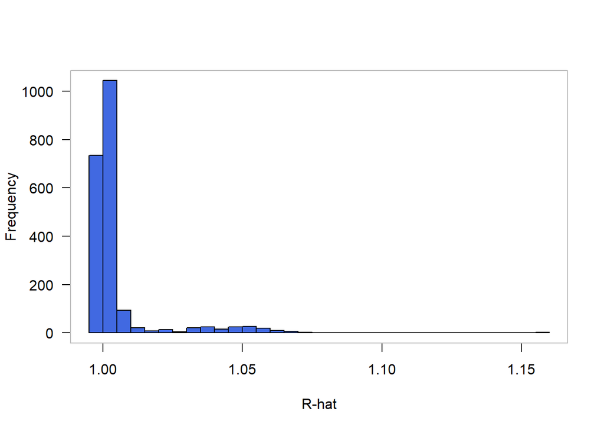

# 3 Key posterior estimates

Biological reference points are in hundreds of thousands and log-normal bias corrected

|  | mean | 2.5% | 50% | 97.5% | n_eff | Rhat |
| --- | --- | --- | --- | --- | --- | --- |
| lnalpha | 0.33 | 0.04 | 0.31 | 0.74 | 899.1 | 1.00 |
| lnalpha_c | 0.57 | 0.22 | 0.52 | 1.07 | 538.7 | 1.01 |
| beta | 0.03 | 0.00 | 0.03 | 0.07 | 858.7 | 1.00 |
| sigma_R | 0.53 | 0.42 | 0.52 | 0.67 | 1189.9 | 1.00 |
| sigma_R0 | 0.52 | 0.21 | 0.47 | 1.12 | 783.5 | 1.01 |
| phi | 0.58 | 0.35 | 0.59 | 0.80 | 725.6 | 1.00 |
| S_max | 60.23 | 14.67 | 33.54 | 240.26 | 481.7 | 1.00 |
| S_eq_c | 28.54 | 8.10 | 17.73 | 104.65 | 482.9 | 1.00 |
| S_msy_c | 7.05 | 0.82 | 4.77 | 22.49 | 559.1 | 1.00 |
| U_msy_c | 0.25 | 0.10 | 0.24 | 0.46 | 1241.6 | 1.00 |

# 4 Model Predictions and Fits

## 4.1 Escapement

Observations are blue points and model predictions are median (black line) and 50th and 97.5th intervals

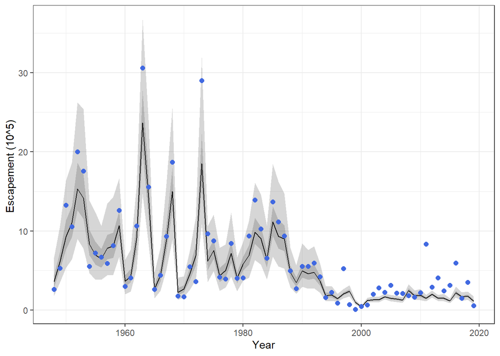

## 4.2 Harvest

Observations are blue points and model predictions are median (black line) and 50th and 97.5th intervals

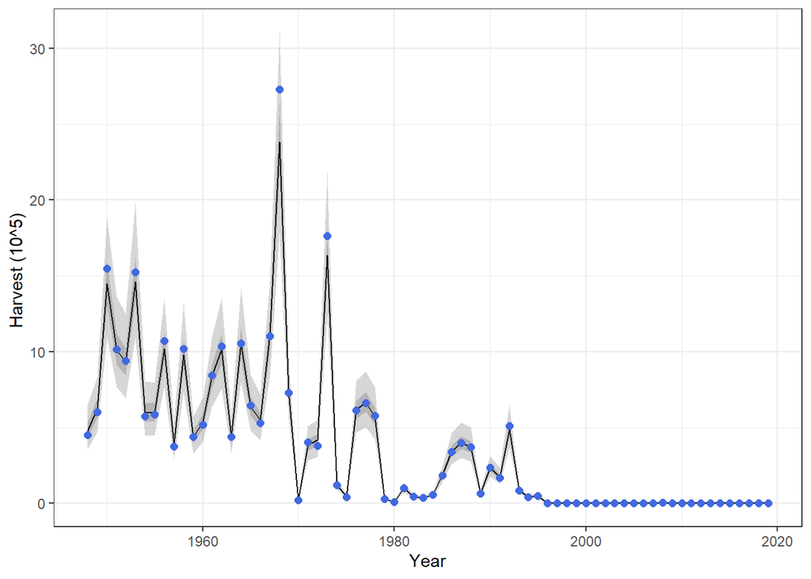

## 4.3 Age composition

Observations are blue points and model predictions are median (black line) and 50th and 97.5th intervals.

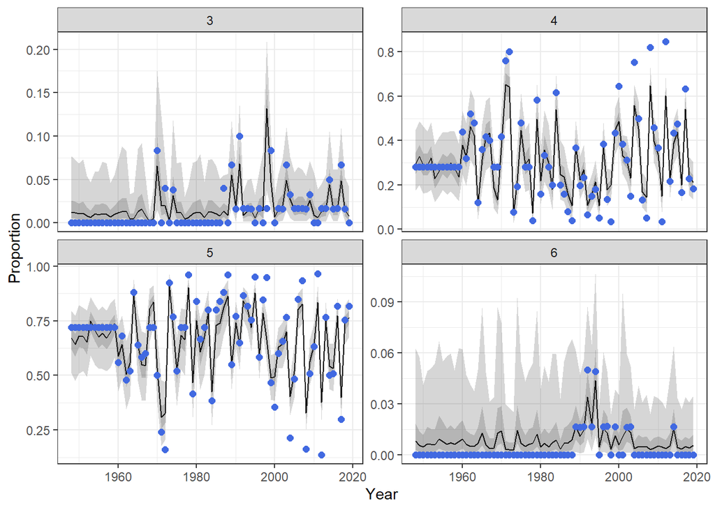

## 4.4 Spawner-recruitment relationship

Predictions are median (black line and points) and 97.5th intervals. Includes recruitment for incomplete brood years at end of time series.

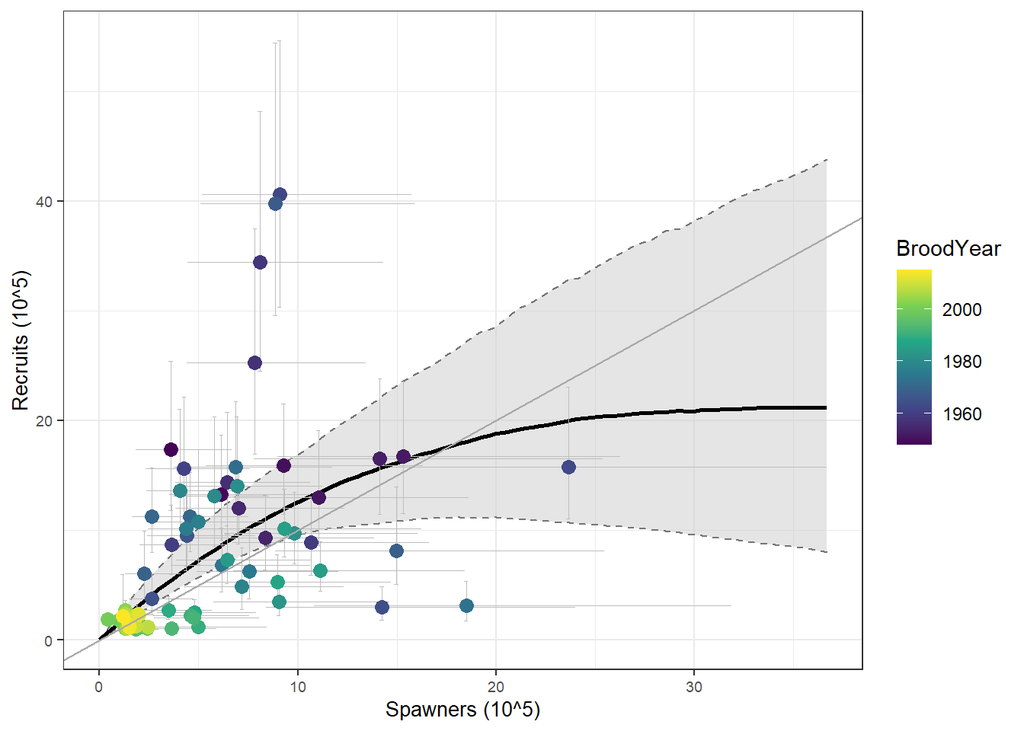

## 4.5 Productivity over time

Predictions are median (black line) and 50th and 97.5th intervals.

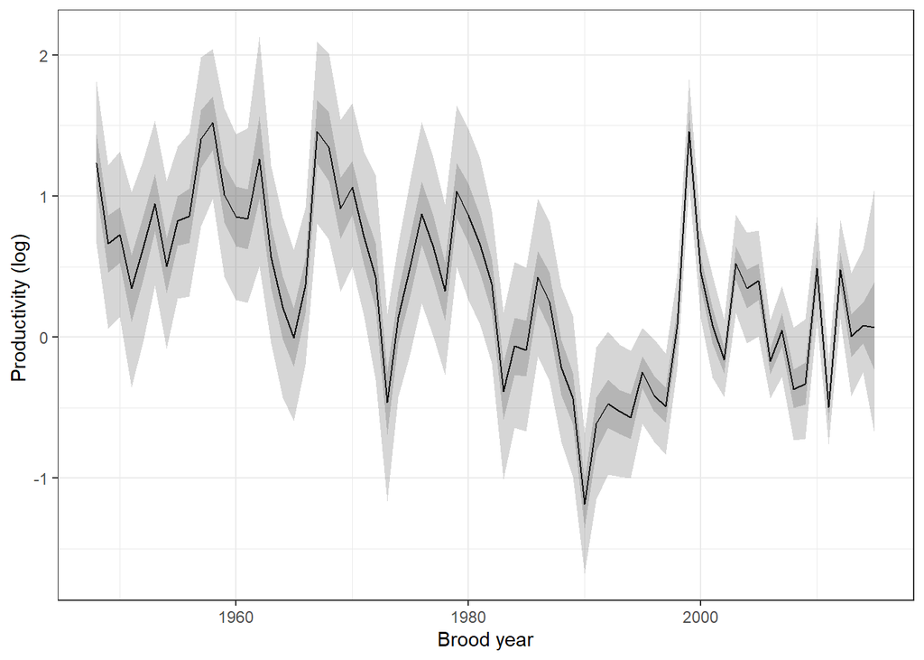

# 5 Model Parameters

Summary of all model parameters.

|  | mean | se_mean | sd | X2.5. | X25. | X50. | X75. | X97.5. | n_eff | Rhat |
| --- | --- | --- | --- | --- | --- | --- | --- | --- | --- | --- |
| lnR[1] | 2.6349 | 0.0205 | 0.5980 | 1.3100 | 2.3093 | 2.6750 | 2.9943 | 3.8232 | 848.97 | 1.0029 |
| lnR[2] | 2.2276 | 0.0090 | 0.2618 | 1.7271 | 2.0553 | 2.2243 | 2.3986 | 2.7402 | 839.59 | 1.0023 |
| lnR[3] | 2.4071 | 0.0050 | 0.1867 | 2.0462 | 2.2812 | 2.4079 | 2.5299 | 2.7703 | 1414.36 | 0.9993 |
| lnR[4] | 3.0368 | 0.0044 | 0.1724 | 2.6799 | 2.9222 | 3.0409 | 3.1556 | 3.3586 | 1523.60 | 1.0032 |
| lnR[5] | 3.0898 | 0.0051 | 0.1839 | 2.7400 | 2.9598 | 3.0890 | 3.2218 | 3.4380 | 1294.07 | 1.0054 |
| lnR[6] | 3.1417 | 0.0056 | 0.2011 | 2.7630 | 3.0074 | 3.1330 | 3.2804 | 3.5319 | 1307.56 | 1.0001 |
| lnR[7] | 3.4122 | 0.0050 | 0.1840 | 3.0449 | 3.2885 | 3.4146 | 3.5387 | 3.7706 | 1353.64 | 1.0002 |
| lnR[8] | 2.8547 | 0.0052 | 0.1983 | 2.4659 | 2.7162 | 2.8551 | 2.9908 | 3.2347 | 1472.15 | 1.0013 |
| lnR[9] | 2.5798 | 0.0051 | 0.1859 | 2.2118 | 2.4546 | 2.5867 | 2.7062 | 2.9257 | 1307.69 | 1.0005 |
| lnR[10] | 2.7647 | 0.0043 | 0.1638 | 2.4367 | 2.6501 | 2.7644 | 2.8790 | 3.0702 | 1466.67 | 1.0003 |
| lnR[11] | 2.5637 | 0.0053 | 0.1995 | 2.1561 | 2.4301 | 2.5615 | 2.7053 | 2.9508 | 1403.06 | 1.0036 |
| lnR[12] | 2.8110 | 0.0046 | 0.1824 | 2.4447 | 2.6928 | 2.8173 | 2.9355 | 3.1582 | 1584.06 | 1.0015 |
| lnR[13] | 2.8017 | 0.0053 | 0.1852 | 2.4368 | 2.6720 | 2.8051 | 2.9290 | 3.1689 | 1204.66 | 1.0017 |
| lnR[14] | 2.2230 | 0.0045 | 0.1864 | 1.8543 | 2.0981 | 2.2273 | 2.3502 | 2.5775 | 1690.47 | 0.9988 |
| lnR[15] | 2.4805 | 0.0039 | 0.1579 | 2.1676 | 2.3754 | 2.4839 | 2.5875 | 2.7817 | 1612.02 | 1.0011 |
| lnR[16] | 2.6638 | 0.0045 | 0.1904 | 2.2679 | 2.5418 | 2.6647 | 2.7882 | 3.0321 | 1763.25 | 0.9998 |
| lnR[17] | 3.2265 | 0.0059 | 0.1981 | 2.8313 | 3.1006 | 3.2294 | 3.3504 | 3.6245 | 1121.05 | 1.0006 |
| lnR[18] | 3.5383 | 0.0045 | 0.1703 | 3.2001 | 3.4244 | 3.5395 | 3.6494 | 3.8745 | 1451.34 | 0.9999 |
| lnR[19] | 2.1837 | 0.0044 | 0.1990 | 1.7812 | 2.0514 | 2.1862 | 2.3163 | 2.5717 | 2038.61 | 0.9987 |
| lnR[20] | 2.1616 | 0.0045 | 0.1865 | 1.7859 | 2.0332 | 2.1587 | 2.2937 | 2.5090 | 1687.71 | 1.0030 |
| lnR[21] | 2.7487 | 0.0041 | 0.1767 | 2.4002 | 2.6326 | 2.7474 | 2.8657 | 3.0967 | 1872.23 | 0.9990 |
| lnR[22] | 3.7019 | 0.0034 | 0.1493 | 3.4119 | 3.6013 | 3.7035 | 3.8008 | 4.0000 | 1877.32 | 1.0009 |
| lnR[23] | 2.7621 | 0.0045 | 0.1870 | 2.4014 | 2.6389 | 2.7597 | 2.8885 | 3.1391 | 1726.78 | 1.0007 |
| lnR[24] | 1.0979 | 0.0087 | 0.2511 | 0.5869 | 0.9287 | 1.0983 | 1.2734 | 1.5768 | 831.07 | 1.0040 |
| lnR[25] | 1.3305 | 0.0076 | 0.2479 | 0.8220 | 1.1696 | 1.3311 | 1.4977 | 1.8028 | 1060.53 | 1.0014 |
| lnR[26] | 2.2547 | 0.0046 | 0.1832 | 1.9029 | 2.1277 | 2.2563 | 2.3838 | 2.5977 | 1572.25 | 0.9998 |
| lnR[27] | 3.6896 | 0.0045 | 0.1555 | 3.3873 | 3.5824 | 3.6829 | 3.7940 | 3.9965 | 1187.93 | 1.0021 |
| lnR[28] | 2.1027 | 0.0078 | 0.2651 | 1.6204 | 1.9171 | 2.0929 | 2.2866 | 2.6365 | 1140.65 | 1.0029 |
| lnR[29] | 1.8046 | 0.0067 | 0.2515 | 1.3175 | 1.6331 | 1.8043 | 1.9736 | 2.2979 | 1418.78 | 1.0049 |
| lnR[30] | 2.4206 | 0.0039 | 0.1739 | 2.0813 | 2.3097 | 2.4216 | 2.5394 | 2.7532 | 1943.91 | 1.0013 |

[output cut: 2057 more lines]